# rAsignment9

Tobias Borzyk

2026-01-11

### For the model selection, any ARIMA parameter combination of p, d, q and the corresponding seasonal components ps, ds, qs should be tested for

###p between 0 and 5, ###d between 0 and 2, ###q between 0 and 5, ###ps between 0 and 2, ###ds between 0 and 2, and ###qs between 0 and 2. ###Please write an Rmd file with html output in which the performance for predicting monthly precipitation of an ARIMA model with all of the possible parameter combinations above is tested.

###The performance should be tested using the RMSE between predicted and observed monthly precipitation for the last two full years of the dataset. Please print the parameters (i.e. p, d, q…) as well as the AIC and RMSE of your optimal model and compare them with the corresponding values retrieved using the forecast::auto.arima function (for the latter you can just use the summary function although it gives more information than necessary). Please also visualize the prediction of your model and the automatically retrieved one in a simple plot (one for each model) and add the actually observed values to the plot. Write a one-sentence-statement about the differences.

```r
library("rdwd")  #dt. Wetterdienst-library herunterladen

## Daten herunterladen
setwd("C:/Users/borzy/Documents/GEOmaster/Data_Analysis")
data_path <- ("C:/Users/borzy/Documents/GEOmaster/Data_Analysis/data/")
url <- rdwd::selectDWD(id = "003164", res = "hourly", var = "precipitation", per = "historical")
rdwd::dataDWD(url, dir = data_path, read = FALSE)
```

[output not shown]

[output not shown]

```r
# adapt path to where your file actually is and filename to the downloaded time span, Daten einlesen
path <- ("C:/Users/borzy/Documents/GEOmaster/Data_Analysis/data/stundenwerte_RR_03164_20060701_20241231_hist/produkt_rr_stunde_20060701_20241231_03164.txt")
dwd <- read.table(path, header = TRUE, sep = ";", dec = ".")
# check
head(dwd)
```

```
##   STATIONS_ID MESS_DATUM QN_8 R1 RS_IND WRTR eor
## 1        3164 2006070100    3  0      0 -999 eor
## 2        3164 2006070101    3  0      0    0 eor
## 3        3164 2006070102    3  0      0    0 eor
## 4        3164 2006070103    3  0      0 -999 eor
## 5        3164 2006070104    3  0      0    0 eor
## 6        3164 2006070105    3  0      0    0 eor
```

```r
# Umwandlung des Datums in ein Datum-Objekt
dwd$DATUM <- strptime(dwd$MESS_DATUM, format = "%Y%m%d%H", tz = "Europe/Berlin")
head(dwd$MESS_DATUM)
```

```
## [1] 2006070100 2006070101 2006070102 2006070103 2006070104 2006070105
```

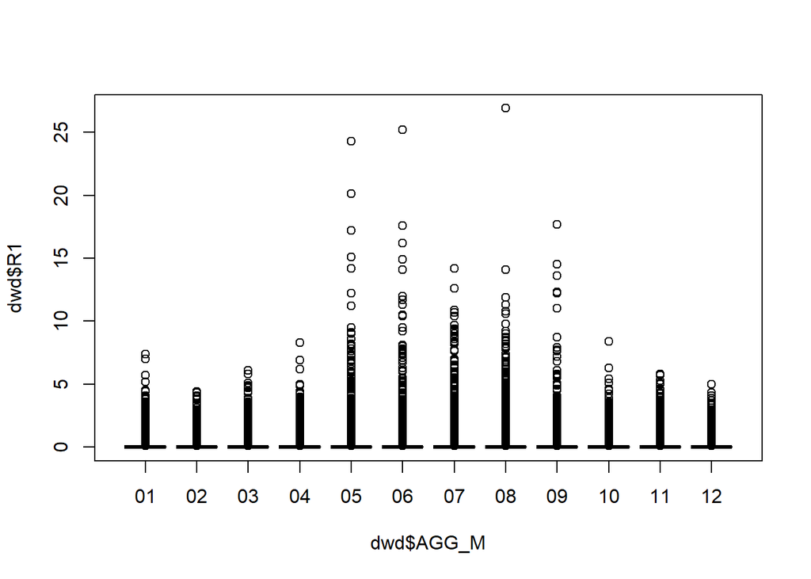

```r
# Entfernen der irrelevanten Zeilen mit -999 im Datensatz
dwd <- dwd[dwd$R1 != -999, ]
dwd <- dwd[dwd$RS_IND != -999, ]

## neues Dataset mit nur Datum und R1 Spalten erstellen
dwd_ns <- dwd[, c("DATUM", "R1")]

# R1 data nach Monaten auswählen
dwd$AGG_M <- substr(dwd$MESS_DATUM, 5, 6)
boxplot(dwd$R1 ~ dwd$AGG_M)
```

```r
#Summe der monatlichen Niederschlagsmenge berechnen
dwd$AGG_JM <- substr(dwd$MESS_DATUM, 1, 6) #Auswahl nach Jahr und Monat
rpm <- aggregate(dwd$R1, by = list(dwd$AGG_JM), FUN = sum) #Summe des Niederschlags nach Monat berechnen
colnames(rpm) <- c("Date", "Precipitation") #Umbennen der Spalten
head(rpm) #check
```

```
##     Date Precipitation
## 1 200607          55.6
## 2 200608         104.7
## 3 200609          10.4
## 4 200610          33.7
## 5 200611          56.6
## 6 200612          44.1
```

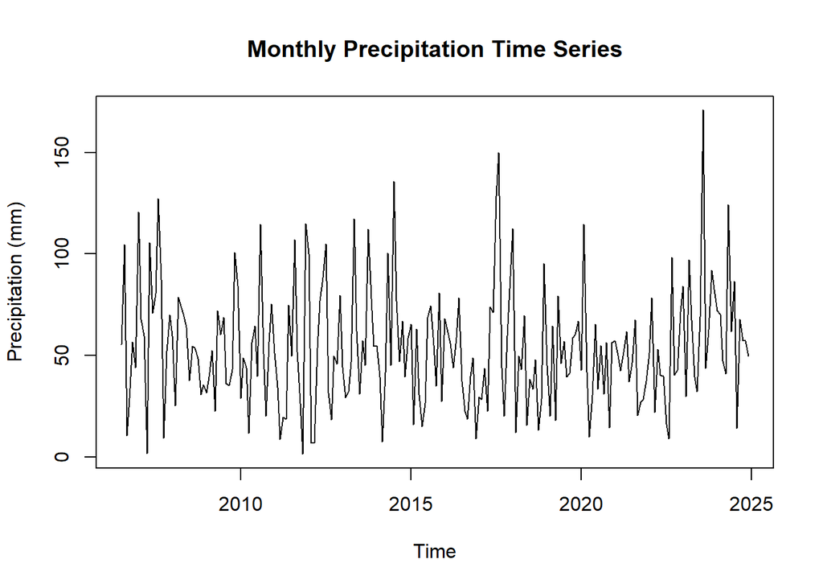

```r
#Timeline erstellen
#Startjahr und Monat herausfiltern
start_year <- as.numeric(substr(rpm$Date[1], 1, 4))
start_month <- as.numeric(substr(rpm$Date[1], 5, 6))

# Zeitreihenobjekt erstellen
precip_ts <- ts(rpm$Precipitation, start = c(start_year, start_month), frequency = 12)

# plotten der Zeitreihe
plot(precip_ts, main = "Monthly Precipitation Time Series", ylab = "Precipitation (mm)", xlab = "Time")
```